# Analyzing visit duration

This is an extra analysis added during peer review.

**Goal:**

Explore whether there was an experimental effect on sighting length (aka “visit duration”, aka how long hummingbird was at inflorescence in camera frame)

**Hypothesis:**

If hummingbirds visited flowers longer after *Heliconia* removal to gain additional calories, then there should be a pre-to-post increase in sighting lengths in treatment replicates (relative to control replicates). This behavioral response would be undetected by the primary response variables.

## Step 1: Get data

```r
#Get data
sighting_durations_for_analysis <- read.csv("../../data/export/for_analysis/Camera_visit_durations.csv") %>%
  mutate(year_patch = paste(year, patch, sep = "_")) %>%
  mutate(exp_phase = factor(exp_phase, levels = c("pre", "post")))

#Source helper functions
source("../../code/helper_functions/Calculate_basic_summary_stats.R")
source("../../code/helper_functions/Summarize_camera_data.R")
source("../../code/helper_functions/Modeling_helper_functions.R")
source("../../code/helper_functions/Plotting_helper_functions.R")
```

## Step 2: Analyze data

If follow framework used in rest of analyses, I would have 4 models:

1. Heliconia tortuosa (HETO), All hummingbird species
2. Heliconia tortuosa (HETO), Green hermits and Violet sabrewings (Heliconia specialists)
3. All non-HETO plant species, All hummingbird species
4. All non-HETO plant species, Green hermits and Violet sabrewings (Heliconia specialists)

However, here the question is not about visitation rates to HETO vs. non-HETO, so I will analyze all plant species together for simplicity. This approach yields 2 models:

1. All plant species, All hummingbird species
2. All plant species, Green hermits and Violet Sabrewings (“*Heliconia* specialists”)

**Model fitting**

For count data, there multiple possible distributions. I need to choose between Poisson and negative binomial (nbinom1 and nbinom2). Also, because the dataset does not include zeroes, I might need a truncated distribution.

ALL HUMMINGBIRD SPECIES

```r
data_all_spp <- sighting_durations_for_analysis %>%
  filter(bird_group == "all_spp")

m1 <- glmmTMB::glmmTMB(sightings_time ~ control_treatment * exp_phase + log(flowers) + offset(log(sightings)) + (1|patch/year_patch/plant_species), data = data_all_spp, na.action = na.omit, family = "truncated_poisson")

m2 <- glmmTMB::glmmTMB(sightings_time ~ control_treatment * exp_phase + log(flowers) + offset(log(sightings)) + (1|patch/year_patch/plant_species), data = data_all_spp, na.action = na.omit, family = "truncated_nbinom1")

m3 <- glmmTMB::glmmTMB(sightings_time ~ control_treatment * exp_phase + log(flowers) + offset(log(sightings)) + (1|patch/year_patch/plant_species), data = data_all_spp, na.action = na.omit, family = "truncated_nbinom2")

m4 <- glmmTMB::glmmTMB(sightings_time ~ control_treatment * exp_phase + log(flowers) + offset(log(sightings)) + (1|patch/year_patch/plant_species), data = data_all_spp, na.action = na.omit, family = "truncated_genpois")

m5 <- glmmTMB::glmmTMB(sightings_time ~ control_treatment * exp_phase + log(flowers) + offset(log(sightings)) + (1|patch/year_patch/plant_species), data = data_all_spp, na.action = na.omit, family = "poisson")

m6 <- glmmTMB::glmmTMB(sightings_time ~ control_treatment * exp_phase + log(flowers) + offset(log(sightings)) + (1|patch/year_patch/plant_species), data = data_all_spp, na.action = na.omit, family = "nbinom1")

m7 <- glmmTMB::glmmTMB(sightings_time ~ control_treatment * exp_phase + log(flowers) + offset(log(sightings)) + (1|patch/year_patch/plant_species), data = data_all_spp, na.action = na.omit, family = "nbinom2")

m8 <- glmmTMB::glmmTMB(sightings_time ~ control_treatment * exp_phase + log(flowers) + offset(log(sightings)) + (1|patch/year_patch/plant_species), data = data_all_spp, na.action = na.omit, family = "genpois")

#Combine models
model_fitting01 <- tibble(model_name = c("m1", "m2", "m3", "m4", "m5", "m6", "m7", "m8"), model = list(m1, m2, m3, m4, m5, m6, m7, m8)) %>%
  mutate(dharma_object = map(model, ~simulateResiduals(fittedModel = ., n = 1000, plot = FALSE, re.form = ~0))) %>%
  mutate(dharma_plot = pmap(list(dharma_object, model_name), ~make_dharma_plot(dharma_object = ..1, plot_title = ..2,  plot_type = "basic")),
         dharma_zeroinfl_plot = pmap(list(dharma_object, model_name), ~make_dharma_plot(dharma_object = ..1, plot_title = ..2,  plot_type = "zeroinflation")),
         dharma_overdisp_plot = pmap(list(dharma_object, model_name), ~make_dharma_plot(dharma_object = ..1, plot_title = ..2,  plot_type = "overdispersion"))) %>%
  mutate(AICc = map(model, MuMIn::AICc))
```

```r
#Which model is best according to AIC?
model_fitting01 %>%
  select(model_name, AICc) %>%
  unnest(AICc) %>%
  arrange(AICc)
```

[output not shown]

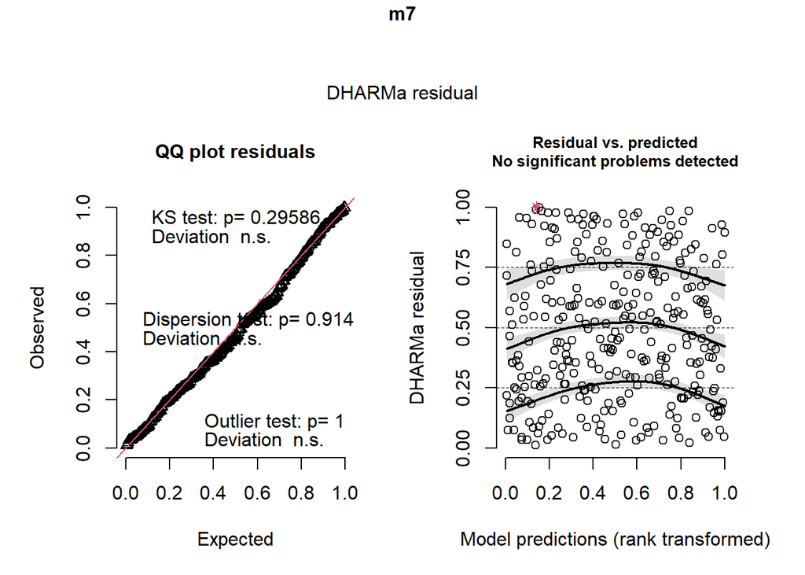

```r
#Check to make sure assumptions look OK
#The models with the lowest AICc actually do not look great. nbinom2 (m7) is best in terms of DHARMa plots
model_fitting01$dharma_plot[[7]]
```

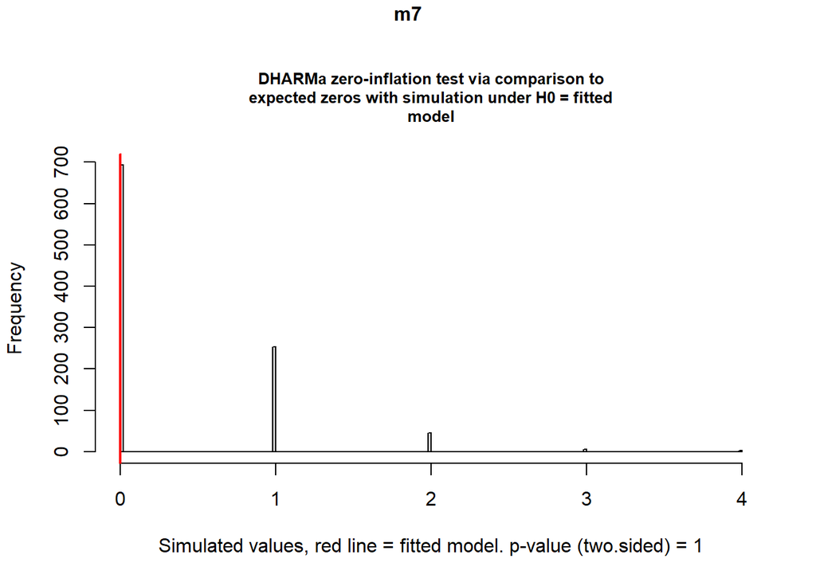

```r
model_fitting01$dharma_zeroinfl_plot[[7]]
```

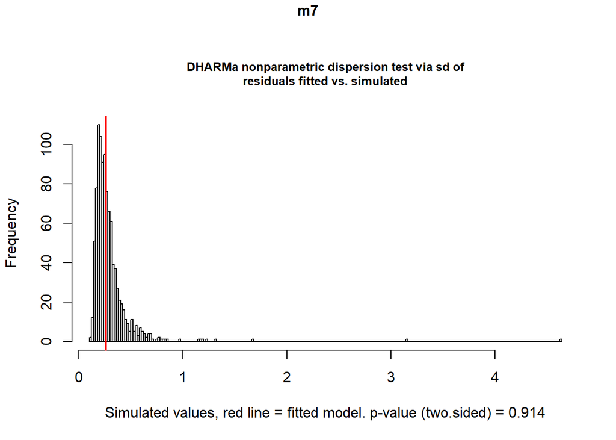

```r
model_fitting01$dharma_overdisp_plot[[7]]
```

HELICONIA SPECIALISTS

```r
data_greh_visa <- sighting_durations_for_analysis %>%
  filter(bird_group == "greh_visa")

m1 <- glmmTMB::glmmTMB(sightings_time ~ control_treatment * exp_phase + log(flowers) + offset(log(sightings)) + (1|patch/year_patch/plant_species), data = data_greh_visa, na.action = na.omit, family = "truncated_poisson")

m2 <- glmmTMB::glmmTMB(sightings_time ~ control_treatment * exp_phase + log(flowers) + offset(log(sightings)) + (1|patch/year_patch/plant_species), data = data_greh_visa, na.action = na.omit, family = "truncated_nbinom1")

m3 <- glmmTMB::glmmTMB(sightings_time ~ control_treatment * exp_phase + log(flowers) + offset(log(sightings)) + (1|patch/year_patch/plant_species), data = data_greh_visa, na.action = na.omit, family = "truncated_nbinom2")

m4 <- glmmTMB::glmmTMB(sightings_time ~ control_treatment * exp_phase + log(flowers) + offset(log(sightings)) + (1|patch/year_patch/plant_species), data = data_greh_visa, na.action = na.omit, family = "truncated_genpois")

m5 <- glmmTMB::glmmTMB(sightings_time ~ control_treatment * exp_phase + log(flowers) + offset(log(sightings)) + (1|patch/year_patch/plant_species), data = data_greh_visa, na.action = na.omit, family = "poisson")

m6 <- glmmTMB::glmmTMB(sightings_time ~ control_treatment * exp_phase + log(flowers) + offset(log(sightings)) + (1|patch/year_patch/plant_species), data = data_greh_visa, na.action = na.omit, family = "nbinom1")

m7 <- glmmTMB::glmmTMB(sightings_time ~ control_treatment * exp_phase + log(flowers) + offset(log(sightings)) + (1|patch/year_patch/plant_species), data = data_greh_visa, na.action = na.omit, family = "nbinom2")

m8 <- glmmTMB::glmmTMB(sightings_time ~ control_treatment * exp_phase + log(flowers) + offset(log(sightings)) + (1|patch/year_patch/plant_species), data = data_greh_visa, na.action = na.omit, family = "genpois")

#Combine models
model_fitting02 <- tibble(model_name = c("m1", "m2", "m3", "m4", "m5", "m6", "m7", "m8"), model = list(m1, m2, m3, m4, m5, m6, m7, m8)) %>%
  mutate(dharma_object = map(model, ~simulateResiduals(fittedModel = ., n = 1000, plot = FALSE, re.form = ~0))) %>%
  mutate(dharma_plot = pmap(list(dharma_object, model_name), ~make_dharma_plot(dharma_object = ..1, plot_title = ..2,  plot_type = "basic")),
         dharma_zeroinfl_plot = pmap(list(dharma_object, model_name), ~make_dharma_plot(dharma_object = ..1, plot_title = ..2,  plot_type = "zeroinflation")),
         dharma_overdisp_plot = pmap(list(dharma_object, model_name), ~make_dharma_plot(dharma_object = ..1, plot_title = ..2,  plot_type = "overdispersion"))) %>%
  mutate(AICc = map(model, MuMIn::AICc))
```

```r
#Which model is best according to AIC?
model_fitting02 %>%
  select(model_name, AICc) %>%
  unnest(AICc) %>%
  arrange(AICc)
```

[output not shown]

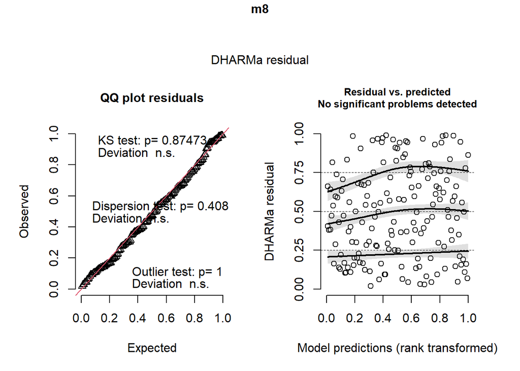

```r
#Check to make sure assumptions look OK
#The models with the lowest AICc actually do not look great. genpois (m8) is best in terms of DHARMa plots
model_fitting02$dharma_plot[[8]]
```

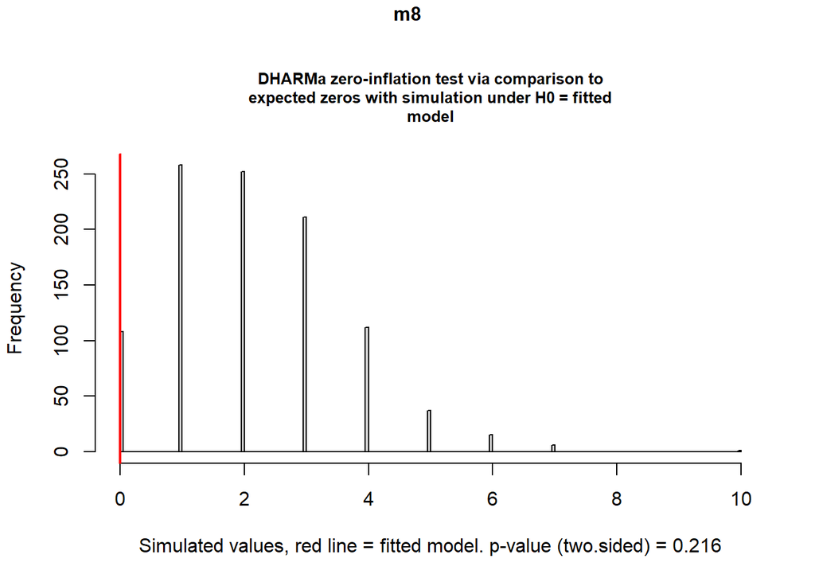

```r
model_fitting02$dharma_zeroinfl_plot[[8]]
```

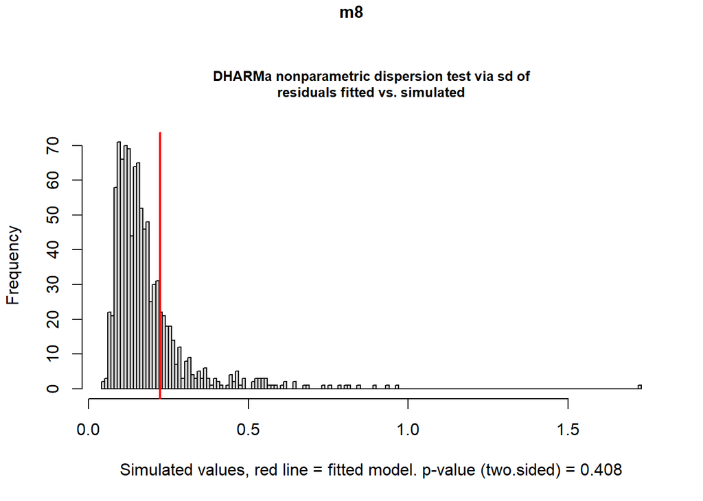

```r
model_fitting02$dharma_overdisp_plot[[8]]
```

**Compile results**

```r
model_all_spp <- model_fitting01$model[[7]]
model_greh_visa <- model_fitting02$model[[8]]

#Model summaries
results_tidy <- broom.mixed::tidy(model_all_spp) %>%
  mutate(bird_group = "all_spp") %>%
  bind_rows(broom.mixed::tidy(model_greh_visa)) %>%
  mutate(bird_group = ifelse(is.na(bird_group), "greh_visa", bird_group)) %>%
  select(bird_group, everything()) %>%
  mutate(pvalue_round = format.pval(pv = round(p.value, 3), digits = 3, nsmall = 3, eps = 0.001)) %>%
  mutate(across(c(estimate, std.error, statistic), ~round(., digits = 3))) %>%
  select(-p.value)

#Estimated marginal means
#Bias adjustment using random effect SDs
bias_adjust_values <- results_tidy %>%
  filter(effect == "ran_pars") %>%
  mutate(estimate2 = estimate^2) %>%
  group_by(bird_group) %>%
  summarise(sum_estimate2 = sum(estimate2)) %>%
  ungroup() %>%
  mutate(sigma = sqrt(sum_estimate2))

sigma_all_spp <- filter(bias_adjust_values, bird_group == "all_spp") %>% pull(sigma)
sigma_greh_visa <- filter(bias_adjust_values, bird_group == "greh_visa") %>% pull(sigma)

#Offset of 1 gives the average sighting length (i.e., estimated amount of time, in seconds, for 1 sighting)
(emmeans_all_spp <- emmeans(model_all_spp, specs = ~exp_phase:control_treatment, type = "response", offset = log(1), bias.adjust = TRUE, sigma = sigma_all_spp) %>%
  as.data.frame() %>%
  rename(estimate = response) %>%
  mutate_if(is.numeric, ~round(., digits = 2)))
```

```
##   exp_phase control_treatment estimate   SE  df lower.CL upper.CL
## 1       pre           control     9.11 0.56 305     8.07    10.28
## 2      post           control     8.75 0.53 305     7.77     9.87
## 3       pre         treatment     9.32 0.50 305     8.39    10.36
## 4      post         treatment     8.14 0.44 305     7.33     9.05
```

```r
(emmeans_greh_visa <- emmeans(model_greh_visa, specs = ~exp_phase:control_treatment, type = "response", offset = log(1), bias.adjust = TRUE, sigma = sigma_greh_visa) %>%
  as.data.frame() %>%
  rename(estimate = response) %>%
  mutate_if(is.numeric, ~round(., digits = 2)))
```

```
##   exp_phase control_treatment estimate   SE  df lower.CL upper.CL
## 1       pre           control     8.13 0.70 157     6.87     9.63
## 2      post           control     8.37 0.71 157     7.07     9.91
## 3       pre         treatment     9.15 0.61 157     8.02    10.45
## 4      post         treatment     9.15 0.60 157     8.03    10.42
```

**Plot results (interaction plots)**

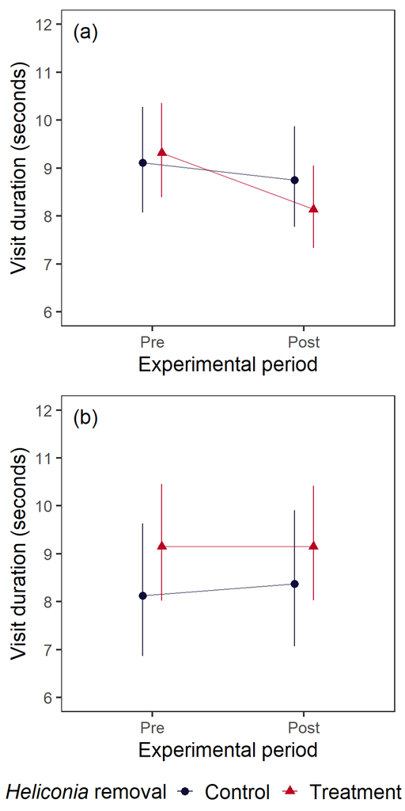

```r
#Sizes for plot elements
size = 18
label_size = size
title_size = size * 1.15
shape_size = 3
line_width = 0.5

#Plots
plot_all_spp <- make_interaction_plot(emmeans_df = emmeans_all_spp, yvar = "visit_duration", ymin = 6, ymax = 12, ybreak = 1, yaccuracy = 1, text_size = size, point_size = shape_size, line_size = line_width, ylabel = "Visit duration (seconds)")

plot_greh_visa <- make_interaction_plot(emmeans_df = emmeans_greh_visa, yvar = "visit_duration", ymin = 6, ymax = 12, ybreak = 1, yaccuracy = 1, text_size = size, point_size = shape_size, line_size = line_width, ylabel = "Visit duration (seconds)")

#Combine into one plot
multiplot <- ggarrange(plot_all_spp, plot_greh_visa, nrow = 2, common.legend = TRUE, legend = "bottom", labels = c("(a)", "(b)"), font.label = list(size = label_size, face = "plain"), label.x = 0.15, label.y = 0.96)

multiplot
```

```r
# ggview::ggview(multiplot, width = 5, height = 10, unit = "in")
```

**Export results**

```r
#SUMMARY TABLES
path_name <- c("../../results/analysis/tables")

#All results tables
write.csv(results_tidy, file.path(path_name, "Hummingbird_visit_duration_results_model_summaries.csv"))
```